# 主成分分析

```python
%matplotlib inline
import numpy as np
import matplotlib.pyplot as plt
```

## 訓練データ生成

```python
n_sample = 100

def gen_data(n_sample):
    mean = [0, 0]
    cov = [[2, 0.7], [0.7, 1]]
    return np.random.multivariate_normal(mean, cov, n_sample) #多次元正規分布 を作るときに使用する。今回は二変数。

def plt_data(X):
    plt.scatter(X[:, 0], X[:, 1])
    plt.xlim(-5, 5)
    plt.ylim(-5, 5)
```

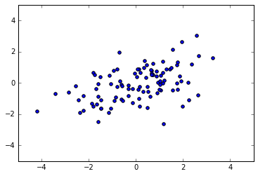

```python
X = gen_data(n_sample)
plt_data(X)
```

## 学習

訓練データ$X = [\boldsymbol{x}_{1}, \boldsymbol{x}_{2}, ..., \boldsymbol{x}_{n}]^{\mathrm{T}}$に対して$\mathbb{E}[\boldsymbol{x}] = \boldsymbol{0}$となるように変換する。

すると、不偏共分散行列は$Var[\boldsymbol{x}] = \frac{1}{n-1} X^{\mathrm{T}}X$と書ける。

$Var[\boldsymbol{x}]$を固有値分解し、固有値の大きい順に対応する固有ベクトルを第1主成分($\boldsymbol{w}_{1}$), 第2主成分($\boldsymbol{w}_{2}$), ...とよぶ。

```python
n_components=2

def get_moments(X):
    mean = X.mean(axis=0) #axis=0は列方向。axis=1は行方向。
    stan_cov = np.dot((X - mean).T, X - mean) / (len(X) - 1) #分散共分散行列を算出。
    return mean, stan_cov

def get_components(eigenvectors, n_components): #指定された数の固有ベクトルを返す。
#     W = eigenvectors[:, -n_components:]
#     return W.T[::-1]
    W = eigenvectors[:, ::-1][:, :n_components]
    return W.T

def plt_result(X, first, second): #第二引数に第一主成分、第三主成分に第二主成分を引数としてとる。
    plt.scatter(X[:, 0], X[:, 1])
    plt.xlim(-5, 5)
    plt.ylim(-5, 5)
    # 第１主成分
    plt.quiver(0, 0, first[0], first[1], width=0.01, scale=6, color='red') #plt.quiverはベクトルを描画する際に使用する関数。
    # 第２主成分
    plt.quiver(0, 0, second[0], second[1], width=0.01, scale=6, color='green')
```

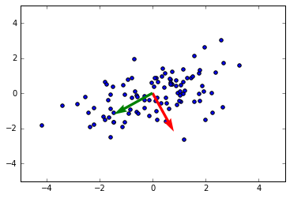

```python
#分散共分散行列を標準化
meean, stan_cov = get_moments(X)
#固有値と固有ベクトルを計算
#この時、算出される固有値は昇順。（リファレンス参照）
#⇨https://docs.scipy.org/doc/numpy-1.15.1/reference/generated/numpy.linalg.eigh.html
eigenvalues, eigenvectors = np.linalg.eigh(stan_cov)
components = get_components(eigenvectors, n_components)

plt_result(X, eigenvectors[0, :], eigenvectors[1, :])
```

## 変換（射影）

元のデータを$m$次元に変換(射影)するときは行列$W$を$W=[\boldsymbol{w}_{1}, \boldsymbol{w}_{2}, \cdots, \boldsymbol{w}_{m}]$とし、データ点$\boldsymbol{x}$を$\boldsymbol{z} = W^{\mathrm{T}} \boldsymbol{x}$によって変換(射影)する。

```python
def transform_by_pca(X, pca):
    mean = X.mean(axis=0)
    return np.dot(X-mean, components)
```

```
(-5, 5)
```

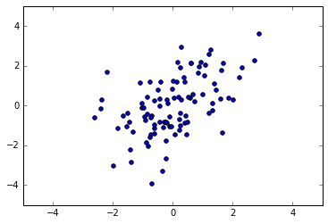

```python
Z = transform_by_pca(X, components.T)
plt.scatter(Z[:, 0], Z[:, 1])
plt.xlim(-5, 5)
plt.ylim(-5, 5)
```

## 逆変換

射影されたデータ点$\boldsymbol{z}$を元のデータ空間へ逆変換するときは$\bar{\boldsymbol{x}} = (W^{\mathrm{T}})^{-1} \boldsymbol{z} = W \boldsymbol{z}$によって変換する。

よって、射影されたデータ$Z$に対しては$\bar{X} = ZW^{\mathrm{T}}$によって変換する。

```python
mean = X.mean(axis=0)
X_ = np.dot(Z, components.T) + mean
```

```
(-5, 5)
```

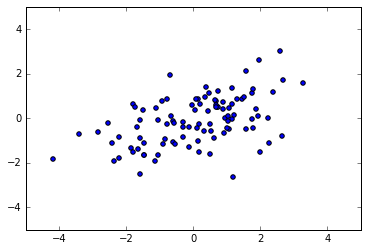

```python
plt.scatter(X_[:, 0], X_[:, 1])
plt.xlim(-5, 5)
plt.ylim(-5, 5)
```

```python
from sklearn.decomposition import PCA
pca = PCA(n_components=2)
pca.fit(X)
```

```
PCA(copy=True, iterated_power='auto', n_components=2, random_state=None,
  svd_solver='auto', tol=0.0, whiten=False)
```

```python
print('components: {}'.format(pca.components_))
print('mean: {}'.format(pca.mean_))
print('covariance: {}'.format(pca.get_covariance()))
```

```
components: [[-0.87501552 -0.48409487]
 [ 0.48409487 -0.87501552]]
mean: [ 0.07920755 -0.09825651]
covariance: [[2.19755266 0.79959687]
 [0.79959687 1.19462826]]
```

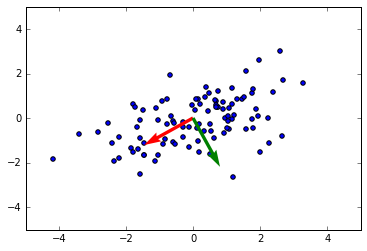

```python
plt_result(X, pca.components_[0, :], pca.components_[1, :])
```

```
components: [[-0.87501552 -0.48409487]
 [ 0.48409487 -0.87501552]]
mean: [ 0.07920755 -0.09825651]
covariance: [[2.19755266 0.79959687]
 [0.79959687 1.19462826]]
```

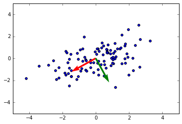

```python
from sklearn.decomposition import PCA
pca = PCA(n_components=2)
pca.fit(X)
plt_result(X, pca.components_[0, :], pca.components_[1, :])

print('components: {}'.format(pca.components_))
print('mean: {}'.format(pca.mean_))
print('covariance: {}'.format(pca.get_covariance()))
```

# 考察

主成分分析により、3つ学んだことがある。  
・高次元から低次元に落とす手法を学んだ(出来るだけ情報量を損なわない)  
・低次元に落とすことで可視化することが可能  
・重要な特徴量を知ることが出来る(分散の大きさ＝固有値)

固有値分解した際に、固有ベクトルが昇順にソートされてしまうのは厄介だなと感じた。(numpyの関数のせい)  
用途によるのは勿論だが、私的にはリアルタイム性を持った重要な特徴量を探索する手法を知りたいと感じる。(仕事の内容ってのもある。)  
そう考えたときに、主成分分析ではなくて固有値分解(特異値分解)を使用する方が使い勝手が良い気がした。(勝手にソートしないし。)